# Supplement 1

Descriptive statistics for the whole cohort

Peter Kamerman and Prinisha Pillay

17 November 2018

This script generates descriptive statistics for variables collected at baseline (visit day: 0, visit_number: 1) for the whole cohort, irrespective of whether they went on to develop sensory neuropathy (SN) or not.

The following data columns were not analysed:

- `pain` and `pain score`: related to SN only, therefore not relevant at baseline when everyone was free from SN.
- `*_record`: inconsistent patient records.
- `hba1c_percent` and `vitaminB12_pmol.l`: These data were only used to classify individuals as having diabetes or vitamin B12 deficiency when cleaning the data *(see:clean-data.R)*.
- `ID`, `visit_number`, `visit_day`, `hivsn_present`, `visit_months`: provide sorting and grouping information only.

# Import data

```r
data <- read_rds('data-clean/clean_data.rds') %>%
    # Filter for visit one
    filter(visit_number == 1) %>%
    # Remove columns that won't be analysed
    select(-starts_with('pain'), -ends_with('_record'),
           -visit_number, -visit_months,
           -hba1c_percent, -vitaminB12_pmol.l)
```

# Inspect data

```r
# Dimensions
dim(data)
```

```
## [1] 83 17
```

```r
# Column names
names(data)
```

```
##  [1] "ID"                     "visit_day"
##  [3] "age_years"              "mass_kg"
##  [5] "height_m"               "sex"
##  [7] "hivsn_present"          "CD4_cell.ul"
##  [9] "viral_load_copies.ml"   "consumes_alcohol"
## [11] "alcohol_units.week"     "TB_current"
## [13] "pyridoxine_prophylaxis" "rifafour_treatment"
## [15] "ARV_regimen"            "diabetic_hba1c"
## [17] "vitaminB12_deficiency"
```

```r
# Head and tail
head(data)
```

```
## # A tibble: 6 x 17
##   ID    visit_day age_years mass_kg height_m sex   hivsn_present
##   <chr>     <int>     <dbl>   <dbl>    <dbl> <fct> <fct>
## 1 001           0        59    41.4     1.56 F     no
## 2 002           0        23    70.2     1.56 F     no
## 3 003           0        27    75       1.64 M     no
## 4 004           0        26    68.8     1.74 M     no
## 5 005           0        37   107       1.6  F     no
## 6 006           0        34    85.5     1.53 F     no
## # ... with 10 more variables: CD4_cell.ul <dbl>,
## #   viral_load_copies.ml <dbl>, consumes_alcohol <fct>,
## #   alcohol_units.week <int>, TB_current <fct>,
## #   pyridoxine_prophylaxis <fct>, rifafour_treatment <fct>,
## #   ARV_regimen <fct>, diabetic_hba1c <fct>, vitaminB12_deficiency <fct>
```

```r
tail(data)
```

```
## # A tibble: 6 x 17
##   ID    visit_day age_years mass_kg height_m sex   hivsn_present
##   <chr>     <int>     <dbl>   <dbl>    <dbl> <fct> <fct>
## 1 078           0        29    54       1.53 F     no
## 2 079           0        44    58.8     1.52 F     no
## 3 080           0        50    53.2     1.51 F     no
## 4 081           0        43    49.5     1.62 F     no
## 5 082           0        40    82.8     1.62 F     no
## 6 083           0        46    73.3     1.66 F     no
## # ... with 10 more variables: CD4_cell.ul <dbl>,
## #   viral_load_copies.ml <dbl>, consumes_alcohol <fct>,
## #   alcohol_units.week <int>, TB_current <fct>,
## #   pyridoxine_prophylaxis <fct>, rifafour_treatment <fct>,
## #   ARV_regimen <fct>, diabetic_hba1c <fct>, vitaminB12_deficiency <fct>
```

```r
# Data structure
glimpse(data)
```

```
## Observations: 83
## Variables: 17
## $ ID                     <chr> "001", "002", "003", "004", "005", "006...
## $ visit_day              <int> 0, 0, 0, 0, 0, 0, 0, 0, 0, 0, 0, 0, 0, ...
## $ age_years              <dbl> 59, 23, 27, 26, 37, 34, 44, 34, 32, 29,...
## $ mass_kg                <dbl> 41.4, 70.2, 75.0, 68.8, 107.0, 85.5, 12...
## $ height_m               <dbl> 1.56, 1.56, 1.64, 1.74, 1.60, 1.53, 1.6...
## $ sex                    <fct> F, F, M, M, F, F, F, F, F, M, M, M, M, ...
## $ hivsn_present          <fct> no, no, no, no, no, no, no, no, no, no,...
## $ CD4_cell.ul            <dbl> 35, 285, 28, 270, 310, 247, 439, 311, 1...
## $ viral_load_copies.ml   <dbl> 6.103804, 5.041393, 5.181844, 2.484300,...
## $ consumes_alcohol       <fct> no, no, no, no, yes, no, no, no, no, no...
## $ alcohol_units.week     <int> 0, 0, 0, 0, 15, 0, 0, 0, 0, 0, 0, 6, 9,...
## $ TB_current             <fct> no, no, yes, no, no, no, no, no, no, no...
## $ pyridoxine_prophylaxis <fct> no, no, yes, no, no, no, no, no, no, no...
## $ rifafour_treatment     <fct> no, no, yes, no, no, no, no, no, no, no...
## $ ARV_regimen            <fct> TDF_FTC_EFV, TDF_FTC_EFV, TDF_FTC_EFV, ...
## $ diabetic_hba1c         <fct> no, no, no, no, no, no, no, no, no, no,...
## $ vitaminB12_deficiency  <fct> no, no, no, no, no, no, no, no, no, no,...
```

# Analyses

## Age

```r
# Tabular summary
data %>%
    select(age_years) %>%
    skim()
```

```
## Skim summary statistics
##  n obs: 83
##  n variables: 1
##
## ── Variable type:numeric ───────────────────────────────────────────────────────────────
##   variable missing complete  n  mean   sd p0 p25 p50 p75 p100     hist
##  age_years       0       83 83 38.67 9.09 21  32  39  44   59 ▂▅▇▆▇▃▂▂
```

```r
# 95% bootstrap confidence interval of the mean age
## Method = BCa, Resamples = 10000
set.seed(1234)
groupwiseMean(age_years ~ 1,
              data = data,
              R = 10000,
              traditional = FALSE,
              boot = TRUE,
              bca = TRUE)[c(2:3, 5, 6, 7)]
```

```
##    n Mean Conf.level Bca.lower Bca.upper
## 1 83 38.7       0.95      36.8      40.6
```

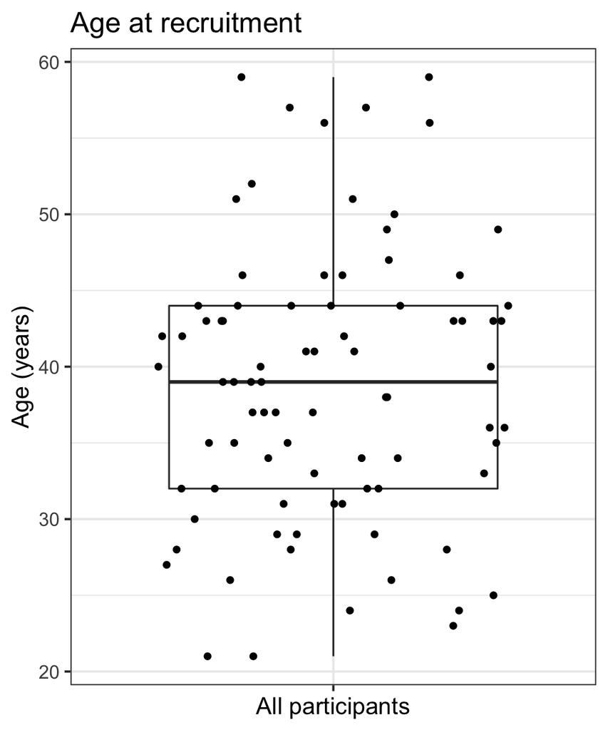

```r
# Plot
data %>%
    ggplot(data = .) +
    aes(y = age_years,
        x = 'All patients') +
    geom_boxplot() +
    geom_jitter(height = 0) +
    labs(title = 'Age at recruitment',
         y = 'Age (years)',
         x = 'All participants') +
    theme(axis.text.x = element_blank())
```

## Body mass

```r
# Tabular summary
data %>%
    select(mass_kg) %>%
    skim()
```

```
## Skim summary statistics
##  n obs: 83
##  n variables: 1
##
## ── Variable type:numeric ───────────────────────────────────────────────────────────────
##  variable missing complete  n  mean    sd   p0 p25  p50   p75  p100
##   mass_kg       0       83 83 66.11 15.97 41.4  54 64.2 75.85 121.4
##      hist
##  ▆▇▆▅▃▁▁▁
```

```r
# 95% bootstrap confidence interval of thew mean age
## Method = BCa, Resamples = 10000
set.seed(1234)
groupwiseMean(mass_kg ~ 1,
              data = data,
              R = 10000,
              traditional = FALSE,
              boot = TRUE,
              bca = TRUE)[c(2:3, 5, 6, 7)]
```

```
##    n Mean Conf.level Bca.lower Bca.upper
## 1 83 66.1       0.95      62.8      69.7
```

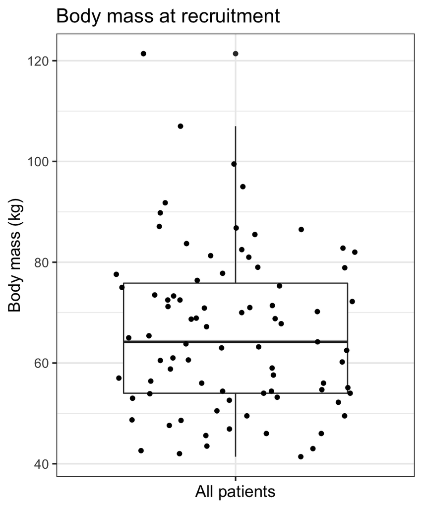

```r
# Plot
data %>%
    ggplot(data = .) +
    aes(y = mass_kg,
        x = 'All patients') +
    geom_boxplot() +
    geom_jitter(height = 0) +
    labs(title = 'Body mass at recruitment',
         y = 'Body mass (kg)') +
    theme(axis.text.x = element_blank())
```